# Demo 9-2 2pm

Wells

9/2/2022

## Layout

4 panels:

1. Upper Left: Editor

2.Lower Left: Console

3. Upper Right: Environment
4. Lower Right: File / Plots / Packages

## The Editor

Components:

- The YAML (at the top)
- Regular text
- Code chunks

```r
1  + 2
```

```
## [1] 3
```

1 + 2

Keyboard shortcut for new code chunk: - Option + CMD + I (mac) - CTRL + ALT + I

## Coding Basics

To make a vector (from scratch)

```r
v <-  c(1, 4, 9, 16, 25)
```

Add 1 to every element in a vector

```r
v + 1
```

```
## [1]  2  5 10 17 26
```

```r
sqrt(v)
```

```
## [1] 1 2 3 4 5
```

Want to take square root of v and make that v

```r
v <- sqrt(v)
```

How to go back?

```r
v <-  c(1, 4, 9, 16, 25)
```

Call the square root vector w

```r
w <- sqrt(v)
```

Converting vectors of numbers to logicals

Which elements of v are > 10?

```r
v > 10
```

```
## [1] FALSE FALSE FALSE  TRUE  TRUE
```

```r
u <- v > 10
```

Other logical operations on vectors:

1. Greater than or equal to: >=
2. Less than: <
3. Less than or equal to: <=
4. Equals: ==
5. Not equals: !=

How many entries of v are greater than 10?

In R, True is coded as 1 and False is coded as 0.

Use sum function on a logical

```r
sum(u)
```

```
## [1] 2
```

```r
sum(v > 10)
```

```
## [1] 2
```

## Functions in R

Suppose we want to square every element of a vector and subtract 1.

write function f(x) = x^2 - 1.

```r
square_minus_one <- function(x){
  x^2 - 1
}
```

Functions of more than one variable:

f(x,y,z) = x*y - z

```r
new_function <- function(variable1, variable2, variable8)
{variable1*variable2 - variable8}
```

## Birthday Problem

Suppose we have k students selecting randomly from integers 1 through n.

The probability of at least 1 match is

1 - n!/((n-k)!n^k)

$$1 - \frac{n!}{(n-k)!n^k} = 1 - \binom{n}{k} \frac{k!}{n^k}$$
Define a function for birthday probability

```r
prob_bday_match <- function(n,k){
  1 - choose(n,k)*factorial(k)/n^k
}
```

## Quick Plotting in R

To make quick graphs, use plot

Plot requires:

1. A vector of inputs
2. A vector of outputs

To create a list of inputs, find equally spaced points in the domain.

Suppose we want birthday probs for 25 students for n between 50 and 1000, in multiples of 25

```r
n <- seq(from = 50, to = 1000, by = 25)
```

create outputs

```r
probs <- prob_bday_match(n, 25)
```

To plot, apply plot function to vector of inputs and outputs

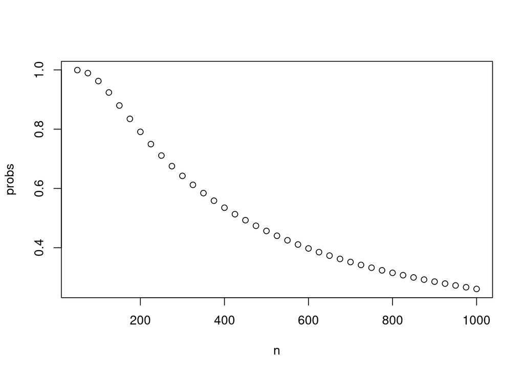

```r
plot(n,probs)
```